# Tutorial 8: Introduction to Pattern Recognition with Neural Networks and PyTorch

CHEE4003: Special Topics A - Artificial Intelligence in Chemical Engineering

Published

October 8, 2026

# What is an artificial neural network?

In previous tutorials, machine-learning models were trained using **scikit-learn**, where most training operations were handled automatically. Typically, users only needed to define a model, fit it to data, and evaluate its predictions. In contrast, this tutorial introduces **PyTorch**, a deep-learning framework that allows users to explicitly define neural-network architectures and implement the training process used to update model parameters.

An **artificial neural network (ANN)** consists of layers of interconnected computational units that transform inputs into outputs. During training, the network learns parameter values that reduce prediction errors through a process of forward propagation, loss evaluation, backpropagation, and optimisation. Unlike many traditional machine-learning models, neural networks can learn complex hierarchical representations directly from data.

The dataset used in this tutorial is the **MNIST handwritten digit dataset**, one of the most widely used benchmark datasets in machine learning. Each observation consists of a grayscale image of a handwritten digit represented by a $28 \times 28$ pixel array. Further details about the dataset are provided below.

Using this collection of handwritten digit images, we will investigate how different neural-network architectures learn patterns from image data by applying and comparing three models:

**1.** a **multilayer perceptron (MLP)** for classification; **2.** a **convolutional neural network (CNN)** for classification; and **3.** a **conditional variational autoencoder (CVAE)** for reconstruction and generation.

Figure 1 provides an overview of the pattern-recognition workflow used throughout this tutorial, the MNIST dataset, and the three neural-network architectures that will be developed and applied.

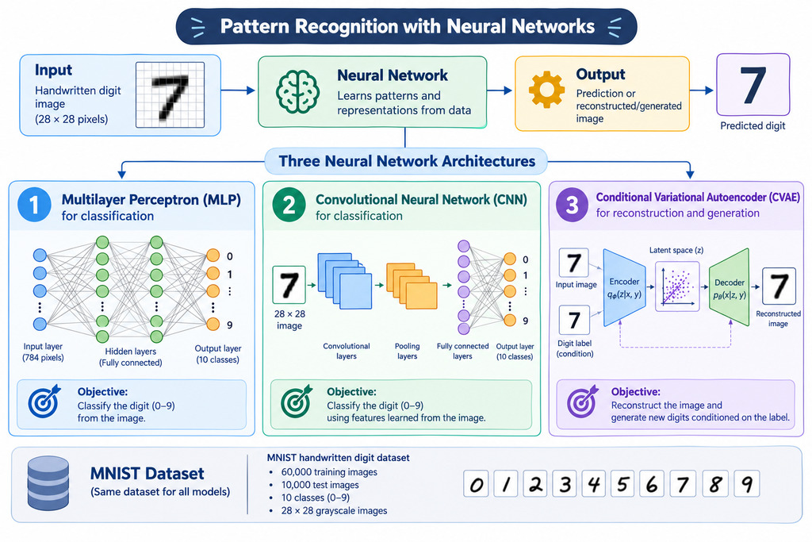

Figure 1: Overview of the MNIST handwritten digit dataset and the three neural-network architectures used in this tutorial.

The core activities are designed for approximately two hours.

| Section | Suggested time |
| --- | --- |
| PyTorch and device quickstart | 15 min |
| MNIST preparation | 10 min |
| MLP classification | 25 min |
| CNN classification | 25 min |
| Conditional VAE | 40 min |
| Synthesis | 5 min |

**NoteLearning objectives**

After completing this tutorial, you will be able to:

1. select CUDA, MPS, or CPU and move PyTorch tensors and models between devices;
2. describe batches, epochs, forward passes, losses, gradients, and optimiser steps;
3. implement and train an MLP and a CNN for image classification;
4. compare the architectural assumptions and predictions of the classifiers;
5. implement and train a conditional variational autoencoder; and
6. sample a Gaussian latent vector to generate examples of a requested digit.

# PyTorch and Google Colab quickstart

[Google Colab](https://colab.research.google.com/) provides a cloud-based notebook environment in which code is organised into executable cells. Create a new notebook and copy each code scaffold from this tutorial into a separate cell before running it. PyTorch is typically pre-installed in Colab, so no additional installation is usually required.

For faster model training, Colab can provide access to a graphics processing unit (GPU). To request a GPU, select **Runtime > Change runtime type**, choose a GPU hardware accelerator, and reconnect the runtime. GPU availability may vary, but all code in this tutorial can also be run using a CPU. The same code can be executed locally on a personal computer if PyTorch is installed.

PyTorch supports several *devices*, which identify the hardware and memory used to store a tensor and perform its calculations:

- `"cuda"` uses a compatible NVIDIA GPU;
- `"mps"` uses the Metal Performance Shaders backend on a compatible Apple computer; and
- `"cpu"` uses the computer’s central processor.

A model and every tensor used in its calculation must be on the same device.

## Imports and reproducibility

Before anything else, we need to have the correct libraries imported. Run the following cell before beginning the tasks.

```
import_libraries.py
```

```python
from pathlib import Path
import random

import matplotlib.pyplot as plt
import numpy as np
import torch
from torch import nn
from torch.nn import functional as F
from torch.utils.data import DataLoader
from torchvision import datasets, transforms
```

Neural-network training includes random parameter initialisation, data shuffling, and, in the conditional variational autoencoder (CVAE), random sampling from a latent probability distribution. Fixing the random seeds makes repeated runs more comparable, although small differences may remain between hardware backends.

```
reproducibility.py
```

```python
def set_seed(seed=42):
    """Seed Python, NumPy and PyTorch for repeatable tutorial runs."""
    random.seed(seed)
    np.random.seed(seed)
    torch.manual_seed(seed)
    if torch.cuda.is_available():
        torch.cuda.manual_seed_all(seed)


set_seed(42)
```

## Selecting a device

Before training a neural network, we need to select the device on which computations will be performed. The following function checks for a compatible NVIDIA GPU (`"cuda"`) first, then the Apple Metal Performance Shaders backend (`"mps"`), and otherwise defaults to the CPU (`"cpu"`). In most cases, the function can be copied and used without modification.

```
select_device.py
```

```python
def select_device():
    """Select CUDA, then Apple MPS, then CPU."""
    if torch.cuda.is_available():
        return torch.device("cuda")
    if hasattr(torch.backends, "mps") and torch.backends.mps.is_available():
        return torch.device("mps")
    return torch.device("cpu")
```

When executed, the function reports the device that will be used for all subsequent computations.

device = select_device()

print(f"Using device: {device}")

Using device: cpu

The native PyTorch method `.to(device)` returns a tensor on the requested device. The same method can also be used to move a model and all of its parameters to the selected device.

example = torch.tensor([1.0, 2.0, 3.0])

example_on_device = example.to(device)

print(f"Original tensor: {example.device}")

Original tensor: cpu

print(f"Moved tensor: {example_on_device.device}")

Moved tensor: cpu

Many Python libraries used for visualisation and data analysis, including Matplotlib and NumPy, expect data to be stored in CPU memory. The native `.cpu()` method moves a tensor back to CPU memory, while `.detach()` disconnects it from the gradient calculations used during training.

To simplify device management, we will use the following helper functions throughout the tutorial. These small convenience functions provide a consistent way to move a tensor, or a batch containing multiple tensors, between devices and CPU memory.

```
device_helpers.py
```

```python
def to_device(data, device):
    """Move a tensor or a tuple/list of tensors to a device."""
    if isinstance(data, tuple):
        return tuple(to_device(item, device) for item in data)
    if isinstance(data, list):
        return [to_device(item, device) for item in data]
    return data.to(device)


def to_cpu(tensor):
    """Detach a tensor from autograd and move it to CPU memory."""
    return tensor.detach().cpu()
```

**NoteNative methods and tutorial helpers**

The methods `tensor.to(device)` and `tensor.cpu()` are built into PyTorch. The functions `to_device()` and `to_cpu()` are helper functions defined specifically for this tutorial to simplify device management. When reading other PyTorch code, you will most commonly encounter the native PyTorch methods.

### Task 1 : Move a tensor between devices

Write `device_round_trip`. The function should move a tensor to the selected `device` using `to_device()`, then create a detached CPU copy using `to_cpu()`. Return both tensors.

**TipImplementation guidance**

First call `to_device(tensor, device)` and store the result. Then pass the moved tensor to `to_cpu()`. Return both outputs so that their `.device` attributes can be inspected and compared.

```
device_round_trip.py
```

```python
def device_round_trip(tensor, device):
    """
    Move a tensor to a selected device and make a detached CPU copy.

    Returns
    -------
    tensor_on_device : torch.Tensor
        The tensor stored on the selected device.
    tensor_on_cpu : torch.Tensor
        A detached copy stored on the CPU.
    """
```

When you run this function, the output will resemble:

tensor_on_device, tensor_on_cpu = device_round_trip(example, device)

print(f"Selected copy: {tensor_on_device.device}")

Selected copy: cpu

print(f"CPU copy: {tensor_on_cpu.device}")

CPU copy: cpu

**Callout-answerAnswer**

```
device_round_trip.py
```

```python
def device_round_trip(tensor, device):
    """
    Move a tensor to a selected device and make a detached CPU copy.

    Returns
    -------
    tensor_on_device : torch.Tensor
        The tensor stored on the selected device.
    tensor_on_cpu : torch.Tensor
        A detached copy stored on the CPU.
    """
    tensor_on_device = to_device(tensor, device)
    tensor_on_cpu = to_cpu(tensor_on_device)
    return tensor_on_device, tensor_on_cpu


tensor_on_device, tensor_on_cpu = device_round_trip(example, device)
print(f"Selected copy: {tensor_on_device.device}")
print(f"CPU copy:      {tensor_on_cpu.device}")
```

## How neural networks train

Although the neural-network architectures used in this tutorial differ, they are all trained using the same underlying process. Understanding this training workflow will help you interpret the code used for the MLP, CNN, and CVAE models later in the tutorial.

| Term | Meaning in this tutorial |
| --- | --- |
| Tensor | A multidimensional array with a shape, data type, and device |
| Batch | A group of samples used to calculate one parameter update |
| Epoch | One pass through every batch in the training data |
| Forward pass | Applying the model to inputs to calculate outputs |
| Loss | A scalar measuring disagreement with the desired output |
| Gradient | The sensitivity of the loss to each trainable parameter |
| Optimiser | The algorithm that uses gradients to update parameters |

For one batch, a standard PyTorch training loop performs five central operations:

```
training_step.py
```

```python
optimizer.zero_grad()               # 1. Remove gradients left by the previous batch
outputs = model(inputs)             # 2. Perform a forward pass
loss = loss_fn(outputs, targets)    # 3. Compute the loss (error)
loss.backward()             # 4. Calculate gradients by backpropagation
optimizer.step()            # 5. Update the model parameters
```

Repeating these operations for every batch completes one **epoch**. Multiple epochs allow the model to revisit every training example, progressively improving its parameter values and reducing the loss.

# Exploring the MNIST dataset

The [MNIST dataset](http://yann.lecun.com/exdb/mnist/) contains 60,000 training images and 10,000 test images. Each image is represented by a grid of $28 \times 28 = 784$ pixel values.

Torchvision represents an image batch with shape

$$[\text{batch},\ \text{channels},\ \text{height},\ \text{width}].$$

Since the images are greyscale, they contain a single channel. In this tutorial, batches are loaded with shape `[128, 1, 28, 28]`, where:

- `128` is the batch size;
- `1` is the number of image channels;
- `28` is the image height; and
- `28` is the image width. The corresponding digit labels are stored in a one-dimensional tensor with shape `[128]`, where each value represents the class associated with an image in the batch.

**NoteWhere the data are stored**

`datasets.MNIST(root=Path("data"), download=True)` stores downloaded files below `data/MNIST/`. In Colab this directory belongs to the temporary notebook session. When the tutorial is run locally, the files remain inside this tutorial project’s `data/` directory.

### Loading MNIST

The following supplied function downloads MNIST and constructs the data loaders used throughout the tutorial. `transforms.ToTensor()` converts each image to a PyTorch tensor with values between 0 and 1. The training loader is shuffled between epochs to help avoid order-dependent updates, while the test loader remains unshuffled. `num_workers=0` provides broad notebook compatibility.

```
mnist_loaders.py
```

```python
def build_mnist_loaders(data_dir=Path("data"), batch_size=128):
    """
    Download MNIST below data_dir and return train/test data loaders.

    Parameters
    ----------
    data_dir : pathlib.Path
        Directory in which Torchvision stores the MNIST folder.
    batch_size : int
        Number of images in each batch.

    Returns
    -------
    train_loader, test_loader : torch.utils.data.DataLoader
        Loaders for the training and test datasets.
    """
    transform = transforms.ToTensor()
    train_data = datasets.MNIST(
        root=data_dir, train=True, download=True, transform=transform
    )
    test_data = datasets.MNIST(
        root=data_dir, train=False, download=True, transform=transform
    )
    train_loader = DataLoader(
        train_data, batch_size=batch_size, shuffle=True, num_workers=0
    )
    test_loader = DataLoader(
        test_data, batch_size=batch_size, shuffle=False, num_workers=0
    )
    return train_loader, test_loader
```

When you run this function, it should yield the following output:

images, labels = next(iter(train_loader))

print(f"Training samples: {len(train_loader.dataset):,}")

Training samples: 60,000

print(f"Test samples: {len(test_loader.dataset):,}")

Test samples: 10,000

print(f"Image batch: {tuple(images.shape)}")

Image batch: (128, 1, 28, 28)

print(f"Label batch: {tuple(labels.shape)}")

Label batch: (128,)

print(f"Pixel range: {images.min().item():.1f} to {images.max().item():.1f}")

Pixel range: 0.0 to 1.0

The training loader contains 469 batches: 468 full batches of 128 images and one smaller final batch. One epoch processes all 60,000 images, regardless of the size of that final batch.

The following supplied function displays the first ten images from a batch. `to_cpu()` makes the plotting code independent of the device used for model training.

```
plot_mnist_batch.py
```

```python
def plot_mnist_batch(images, labels, n=10):
    """Display the first n labelled images from a batch."""
    images = to_cpu(images)
    labels = to_cpu(labels)

    fig, axes = plt.subplots(2, 5, figsize=(10, 4))
    for ax, image, label in zip(axes.flat, images[:n], labels[:n]):
        ax.imshow(image.squeeze(0), cmap="gray", vmin=0, vmax=1)
        ax.set_title(f"Label: {label.item()}")
        ax.axis("off")
    plt.tight_layout()
    plt.show()
```

plot_mnist_batch(images, labels)

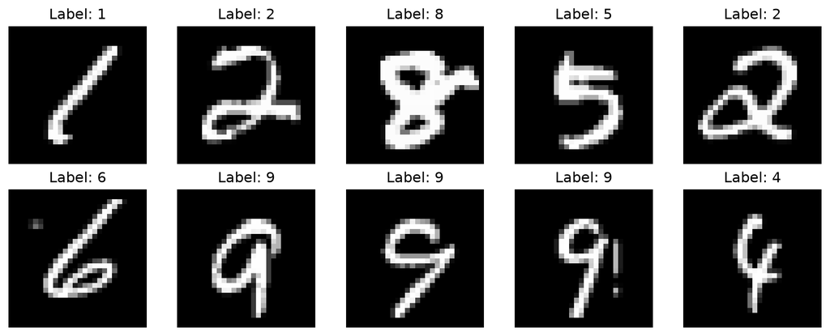

**TipWhy separate training and test data?**

The optimiser uses only the training data to update model parameters. Test accuracy is calculated on separate images to assess how well the trained model generalises to examples it did not train on. We will not use the test data to choose hyperparameters in this introductory tutorial.

## Part A: Multilayer perceptron classification

An **MLP** transforms an input through one or more fully connected (*linear*) layers. A hidden layer first calculates

$$\mathbf{h} = \operatorname{ReLU}(\mathbf{W}_1\mathbf{x}+\mathbf{b}_1),$$

and an output layer then maps these hidden values to ten class scores. The rectified linear unit is

$$\operatorname{ReLU}(a)=\max(0,a).$$

Before the first linear layer, `nn.Flatten()` changes each image from `[1, 28, 28]` to a vector of 784 pixel values:

```
[B, 1, 28, 28] -> Flatten -> Linear(784, 128) -> ReLU -> Linear(128, 10)
```

The final ten values are **logits**: unnormalised scores, one for each digit. Their shape is `[batch, 10]`.

### Task 2 : Build an MLP classifier

Implement `MLPClassifier` using `nn.Sequential`. The output must contain ten logits for every image.

**TipImplementation guidance**

In `__init__`, replace `None` with a sequence containing:

1. `nn.Flatten()`;
2. `nn.Linear(28 * 28, 128)`;
3. `nn.ReLU()`; and
4. `nn.Linear(128, 10)`.

In `forward`, pass `images` through `self.network` and return the result.

```
mlp_classifier.py
```

```python
class MLPClassifier(nn.Module):
    """A two-layer perceptron for 28 x 28 MNIST images."""

    def __init__(self):
        super().__init__()
        self.network = None

    def forward(self, images):
        """Return ten class logits for each image."""
```

mlp = MLPClassifier().to(device)

with torch.no_grad():

sample_logits = mlp(images[:4].to(device))

print(mlp)

MLPClassifier(

(network): Sequential(

(0): Flatten(start_dim=1, end_dim=-1)

(1): Linear(in_features=784, out_features=128, bias=True)

(2): ReLU()

(3): Linear(in_features=128, out_features=10, bias=True)

)

)

print(f"\nMLP output shape: {tuple(sample_logits.shape)}")

MLP output shape: (4, 10)

**ImportantWhy not add softmax?**

`nn.CrossEntropyLoss()` expects raw logits and applies the required log-softmax calculation internally. Adding a softmax layer to the model would duplicate that transformation and can make optimisation less numerically stable.

**Callout-answerAnswer**

```
mlp_classifier.py
```

```python
class MLPClassifier(nn.Module):
    """A two-layer perceptron for 28 x 28 MNIST images."""

    def __init__(self):
        super().__init__()
        self.network = nn.Sequential(
            nn.Flatten(),
            nn.Linear(28 * 28, 128),
            nn.ReLU(),
            nn.Linear(128, 10),
        )

    def forward(self, images):
        return self.network(images)


mlp = MLPClassifier().to(device)
print(mlp)
```

### Task 3 : Train the MLP

Write `train_mlp`. For every batch, move the inputs and labels to `device`, reset the gradients, calculate logits and loss, calculate new gradients, and update the parameters.

Use `nn.CrossEntropyLoss()` and the Adam optimiser with learning rate $10^{-3}$.

**TipImplementation guidance**

Inside the batch loop, the required order is:

1. `batch_images, batch_labels = to_device((batch_images, batch_labels), device)`
2. `optimizer.zero_grad()`
3. `logits = model(batch_images)`
4. `loss = loss_fn(logits, batch_labels)`
5. `loss.backward()`
6. `optimizer.step()`
7. add `loss.item() * batch_images.size(0)` to `running_loss`.

Multiplying the batch mean by its size before accumulating ensures that the smaller final batch receives the correct weight in the epoch mean.

```
train_mlp.py
```

```python
def train_mlp(model, train_loader, device, epochs=3, lr=1e-3):
    """
    Train an MLP and return its mean loss for every epoch.

    Parameters
    ----------
    model : MLPClassifier
        The model to train.
    train_loader : DataLoader
        Batches from the MNIST training set.
    device : torch.device
        Hardware used for training.
    epochs : int
        Number of complete passes through the training set.
    lr : float
        Adam learning rate.

    Returns
    -------
    history : list of float
        Mean training loss for each epoch.
    """
    loss_fn = nn.CrossEntropyLoss()
    optimizer = torch.optim.Adam(model.parameters(), lr=lr)
    history = []

    for epoch in range(epochs):
        model.train()
        running_loss = 0.0

        for batch_images, batch_labels in train_loader:
            # Move the batch, reset gradients, run the model, calculate
            # loss and gradients, update parameters, and accumulate loss.
            pass

        epoch_loss = running_loss / len(train_loader.dataset)
        history.append(epoch_loss)
        print(f"Epoch {epoch + 1}/{epochs} - loss: {epoch_loss:.4f}")

    return history
```

Before training, we need ways to evaluate and inspect a classifier. These supplied helpers work for both the MLP and CNN.

```
classifier_helpers.py
```

```python
def count_parameters(model):
    """Count trainable scalar parameters."""
    return sum(
        parameter.numel()
        for parameter in model.parameters()
        if parameter.requires_grad
    )


@torch.no_grad()
def evaluate_classifier(model, data_loader, device):
    """Return mean cross-entropy loss and accuracy."""
    model.eval()
    loss_fn = nn.CrossEntropyLoss(reduction="sum")
    total_loss = 0.0
    total_correct = 0

    for batch_images, batch_labels in data_loader:
        batch_images, batch_labels = to_device(
            (batch_images, batch_labels), device
        )
        logits = model(batch_images)
        total_loss += loss_fn(logits, batch_labels).item()
        total_correct += (
            logits.argmax(dim=1) == batch_labels
        ).sum().item()

    n_samples = len(data_loader.dataset)
    return total_loss / n_samples, total_correct / n_samples


def plot_training_loss(history, title):
    """Plot mean training loss against epoch number."""
    epochs = np.arange(1, len(history) + 1)
    plt.figure(figsize=(8, 5))
    plt.plot(epochs, history, marker="o")
    plt.xlabel("Epoch")
    plt.ylabel("Mean training loss")
    plt.title(title)
    plt.xticks(epochs)
    plt.grid(True, alpha=0.3)
    plt.show()


@torch.no_grad()
def plot_classifier_predictions(model, data_loader, device, n=10):
    """Plot images with true and predicted labels."""
    model.eval()
    batch_images, batch_labels = next(iter(data_loader))
    predictions = to_cpu(
        model(batch_images.to(device)).argmax(dim=1)
    )
    batch_images = to_cpu(batch_images)

    fig, axes = plt.subplots(2, 5, figsize=(10, 4))
    for ax, image, truth, prediction in zip(
        axes.flat, batch_images[:n], batch_labels[:n], predictions[:n]
    ):
        colour = (
            "black"
            if truth.item() == prediction.item()
            else "crimson"
        )
        ax.imshow(image.squeeze(0), cmap="gray", vmin=0, vmax=1)
        ax.set_title(
            f"True {truth.item()}, predicted {prediction.item()}",
            color=colour,
            fontsize=9,
        )
        ax.axis("off")
    plt.tight_layout()
    plt.show()


@torch.no_grad()
def plot_misclassified_examples(model, data_loader, device, n=10):
    """Find and display the first n classifier errors."""
    model.eval()
    mistakes = []

    for batch_images, batch_labels in data_loader:
        predictions = to_cpu(
            model(batch_images.to(device)).argmax(dim=1)
        )
        wrong = predictions != batch_labels

        for image, truth, prediction in zip(
            batch_images[wrong],
            batch_labels[wrong],
            predictions[wrong],
        ):
            mistakes.append(
                (image, truth.item(), prediction.item())
            )
            if len(mistakes) == n:
                break
        if len(mistakes) == n:
            break

    fig, axes = plt.subplots(2, 5, figsize=(10, 4))
    fig.suptitle("Misclassified examples: true label → prediction")
    for ax, (image, truth, prediction) in zip(
        axes.flat, mistakes
    ):
        ax.imshow(image.squeeze(0), cmap="gray", vmin=0, vmax=1)
        ax.set_title(
            f"{truth} → {prediction}",
            fontsize=9,
        )
        ax.axis("off")
    for ax in axes.flat[len(mistakes):]:
        ax.axis("off")
    plt.tight_layout(rect=(0, 0, 1, 0.94))
    plt.show()
```

set_seed(42)

mlp = MLPClassifier().to(device)

mlp_history = train_mlp(

mlp, train_loader, device, epochs=3

)

Epoch 1/3 - loss: 0.4100

Epoch 2/3 - loss: 0.1925

Epoch 3/3 - loss: 0.1420

mlp_test_loss, mlp_accuracy = evaluate_classifier(

mlp, test_loader, device

)

print(f"Trainable parameters: {count_parameters(mlp):,}")

Trainable parameters: 101,770

print(f"Test loss: {mlp_test_loss:.4f}")

Test loss: 0.1275

print(f"Test accuracy: {100 * mlp_accuracy:.2f}%")

Test accuracy: 96.23%

The loss should fall during training, and a three-epoch MLP will commonly achieve approximately 96–98% test accuracy. Your result may differ slightly because training is stochastic and numerical operations vary between devices.

plot_training_loss(mlp_history, "MLP Training Loss")

plot_classifier_predictions(mlp, test_loader, device)

plot_misclassified_examples(mlp, test_loader, device)

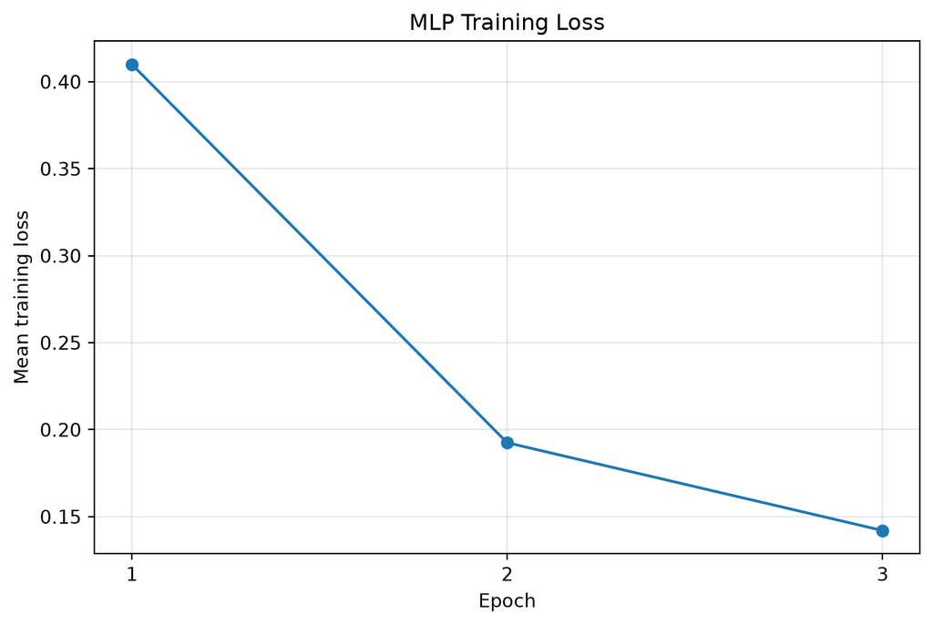

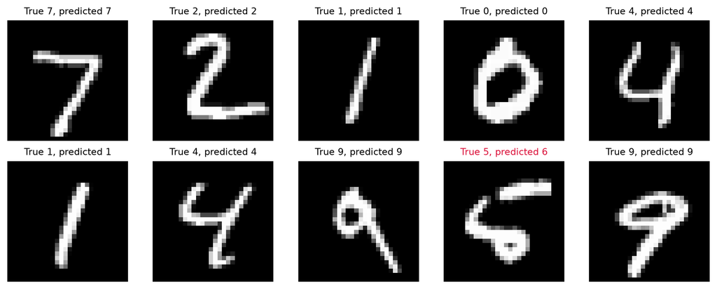

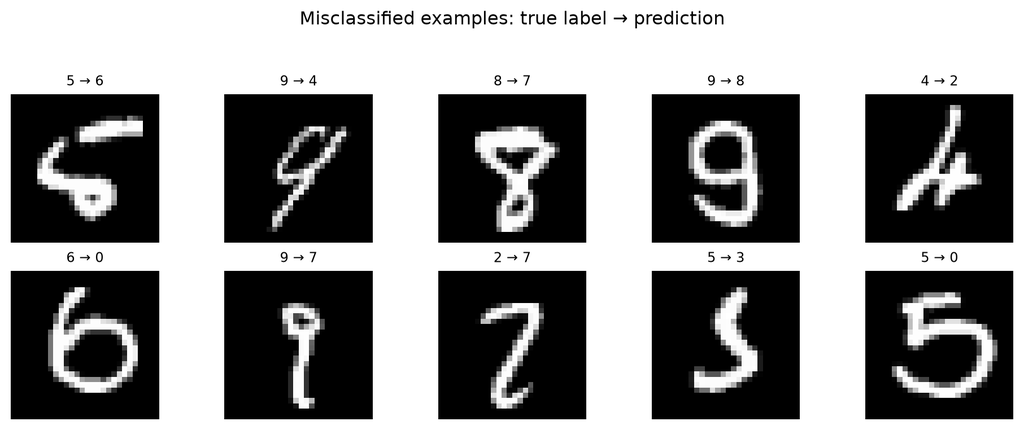

The incorrect predictions are not necessarily unreasonable: some handwritten examples are ambiguous even to a human reader. Inspecting errors complements a numerical accuracy value and can expose systematic failure modes.

**TipApplication to process data**

An MLP can be applied to a vector of process measurements such as temperatures, pressures, flows, and compositions. As with MNIST pixels, scaling, representative training data, and a separate test set remain important even when the inputs are not images.

**Callout-answerAnswer**

```
train_mlp.py
```

```python
def train_mlp(model, train_loader, device, epochs=3, lr=1e-3):
    """
    Train an MLP and return its mean loss for every epoch.
    """
    loss_fn = nn.CrossEntropyLoss()
    optimizer = torch.optim.Adam(model.parameters(), lr=lr)
    history = []

    for epoch in range(epochs):
        model.train()
        running_loss = 0.0

        for batch_images, batch_labels in train_loader:
            batch_images, batch_labels = to_device(
                (batch_images, batch_labels), device
            )
            optimizer.zero_grad()
            logits = model(batch_images)
            loss = loss_fn(logits, batch_labels)
            loss.backward()
            optimizer.step()
            running_loss += (
                loss.item() * batch_images.size(0)
            )

        epoch_loss = (
            running_loss / len(train_loader.dataset)
        )
        history.append(epoch_loss)
        print(
            f"Epoch {epoch + 1}/{epochs} - "
            f"loss: {epoch_loss:.4f}"
        )

    return history


set_seed(42)
mlp = MLPClassifier().to(device)
mlp_history = train_mlp(
    mlp, train_loader, device, epochs=3
)
```

## Part B: Convolutional neural network classification

The MLP flattened each image before learning from it. Consequently, two pixels that were neighbours in the original image are treated no differently from two pixels at opposite corners.

A **convolutional neural network (CNN)** preserves the two-dimensional arrangement. A small learnable filter slides across the image and responds to a local pattern wherever it occurs. Early filters can respond to edges or strokes, while later layers combine these responses into more complex features.

A convolutional layer produces **feature maps**. `nn.ReLU()` introduces nonlinearity, and `nn.MaxPool2d(2)` retains the largest value in each $2 \times 2$ region, halving the height and width.

| Operation | Output shape |
| --- | --- |
| Input batch | `[B, 1, 28, 28]` |
| 16 padded $3 \times 3$ filters | `[B, 16, 28, 28]` |
| $2 \times 2$ max pooling | `[B, 16, 14, 14]` |
| 32 padded $3 \times 3$ filters | `[B, 32, 14, 14]` |
| $2 \times 2$ max pooling | `[B, 32, 7, 7]` |
| Flatten | `[B, 1568]` |
| Fully connected classifier | `[B, 10]` |

Padding by one pixel on each boundary keeps the height and width unchanged for a $3 \times 3$ convolution. Pooling is what reduces 28 to 14 and then 14 to 7.

### Task 4 : Build a CNN classifier

Implement `CNNClassifier`. Use the convolution and pooling layers from the table, then a fully connected classifier with a 128-neuron hidden layer.

**TipImplementation guidance**

The `features` sequence should contain:

1. `nn.Conv2d(1, 16, kernel_size=3, padding=1)`, ReLU and max pooling;
2. `nn.Conv2d(16, 32, kernel_size=3, padding=1)`, ReLU and max pooling.

The `classifier` sequence should flatten `32 * 7 * 7` values, map them to 128 hidden values with ReLU, and produce ten logits.

In `forward`, calculate the feature maps first and pass them to the classifier.

```
cnn_classifier.py
```

```python
class CNNClassifier(nn.Module):
    """A compact convolutional classifier for MNIST."""

    def __init__(self):
        super().__init__()
        self.features = None
        self.classifier = None

    def forward(self, images):
        """Return ten class logits for each image."""
```

cnn = CNNClassifier().to(device)

with torch.no_grad():

sample_feature_maps = cnn.features(

images[:4].to(device)

)

sample_logits = cnn(images[:4].to(device))

print(cnn)

CNNClassifier(

(features): Sequential(

(0): Conv2d(1, 16, kernel_size=(3, 3), stride=(1, 1), padding=(1, 1))

(1): ReLU()

(2): MaxPool2d(kernel_size=2, stride=2, padding=0, dilation=1, ceil_mode=False)

(3): Conv2d(16, 32, kernel_size=(3, 3), stride=(1, 1), padding=(1, 1))

(4): ReLU()

(5): MaxPool2d(kernel_size=2, stride=2, padding=0, dilation=1, ceil_mode=False)

)

(classifier): Sequential(

(0): Flatten(start_dim=1, end_dim=-1)

(1): Linear(in_features=1568, out_features=128, bias=True)

(2): ReLU()

(3): Linear(in_features=128, out_features=10, bias=True)

)

)

print(

f"\nFeature-map shape: {tuple(sample_feature_maps.shape)}"

)

Feature-map shape: (4, 32, 7, 7)

print(f"CNN output shape: {tuple(sample_logits.shape)}")

CNN output shape: (4, 10)

**Callout-answerAnswer**

```
cnn_classifier.py
```

```python
class CNNClassifier(nn.Module):
    """A compact convolutional classifier for MNIST."""

    def __init__(self):
        super().__init__()
        self.features = nn.Sequential(
            nn.Conv2d(
                1, 16, kernel_size=3, padding=1
            ),
            nn.ReLU(),
            nn.MaxPool2d(2),
            nn.Conv2d(
                16, 32, kernel_size=3, padding=1
            ),
            nn.ReLU(),
            nn.MaxPool2d(2),
        )
        self.classifier = nn.Sequential(
            nn.Flatten(),
            nn.Linear(32 * 7 * 7, 128),
            nn.ReLU(),
            nn.Linear(128, 10),
        )

    def forward(self, images):
        features = self.features(images)
        return self.classifier(features)


cnn = CNNClassifier().to(device)
print(cnn)
```

### Task 5 : Train the CNN

Write `train_cnn`. The optimisation sequence is the same as for the MLP even though the forward calculation now contains convolutions.

Writing the loop again reinforces which PyTorch operations are required for every supervised training batch.

**TipImplementation guidance**

Use `nn.CrossEntropyLoss()` and `torch.optim.Adam`. Within each batch, use the same seven operations as in `train_mlp`:

1. move the images and labels to `device`;
2. reset gradients;
3. calculate logits;
4. calculate the loss;
5. run `backward()`;
6. update the parameters; and
7. accumulate the sample-weighted loss.

```
train_cnn.py
```

```python
def train_cnn(model, train_loader, device, epochs=3, lr=1e-3):
    """
    Train a CNN and return its mean loss for every epoch.

    Parameters
    ----------
    model : CNNClassifier
        The model to train.
    train_loader : DataLoader
        Batches from the MNIST training set.
    device : torch.device
        Hardware used for training.
    epochs : int
        Number of complete passes through the training set.
    lr : float
        Adam learning rate.

    Returns
    -------
    history : list of float
        Mean training loss for each epoch.
    """
    loss_fn = nn.CrossEntropyLoss()
    optimizer = torch.optim.Adam(
        model.parameters(), lr=lr
    )
    history = []

    for epoch in range(epochs):
        model.train()
        running_loss = 0.0

        for batch_images, batch_labels in train_loader:
            # Move the batch, reset gradients, run the model, calculate
            # loss and gradients, update parameters, and accumulate loss.
            pass

        epoch_loss = (
            running_loss / len(train_loader.dataset)
        )
        history.append(epoch_loss)
        print(
            f"Epoch {epoch + 1}/{epochs} - "
            f"loss: {epoch_loss:.4f}"
        )

    return history
```

set_seed(42)

cnn = CNNClassifier().to(device)

cnn_history = train_cnn(

cnn, train_loader, device, epochs=3

)

Epoch 1/3 - loss: 0.3142

Epoch 2/3 - loss: 0.0733

Epoch 3/3 - loss: 0.0516

cnn_test_loss, cnn_accuracy = evaluate_classifier(

cnn, test_loader, device

)

print(f"Trainable parameters: {count_parameters(cnn):,}")

Trainable parameters: 206,922

print(f"Test loss: {cnn_test_loss:.4f}")

Test loss: 0.0404

print(f"Test accuracy: {100 * cnn_accuracy:.2f}%")

Test accuracy: 98.57%

A three-epoch CNN will commonly achieve approximately 98–99% test accuracy. This range is a guide rather than a pass criterion.

plot_training_loss(cnn_history, "CNN Training Loss")

plot_classifier_predictions(cnn, test_loader, device)

plot_misclassified_examples(cnn, test_loader, device)

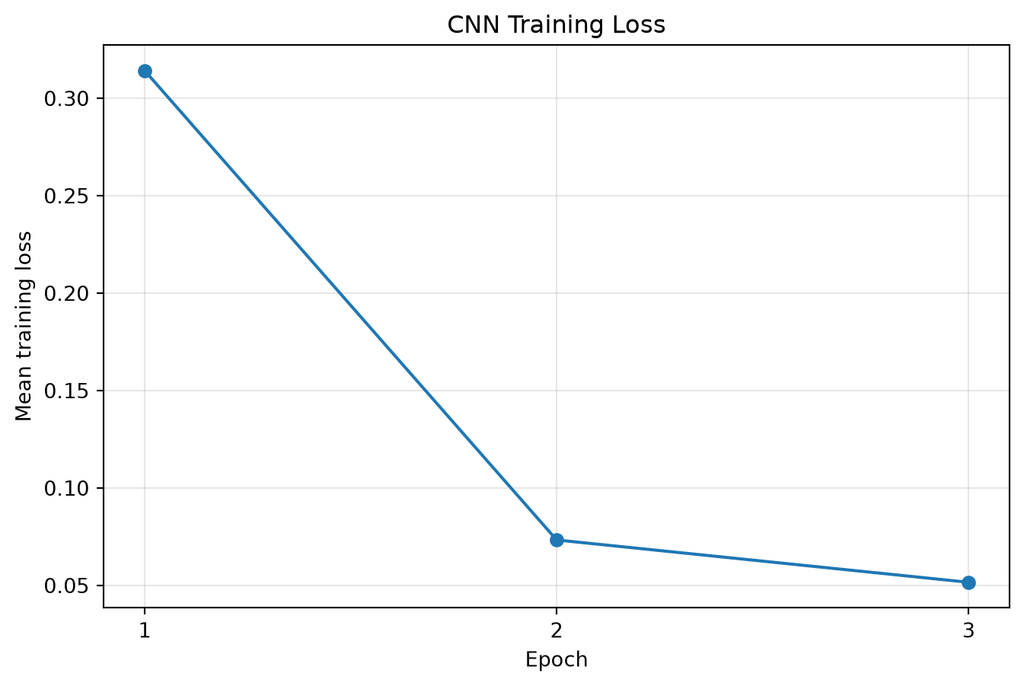

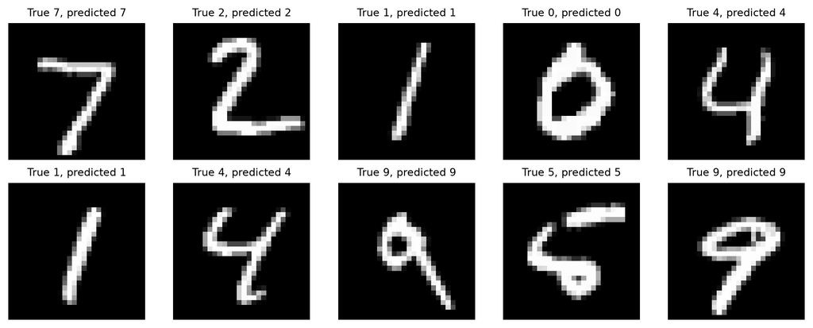

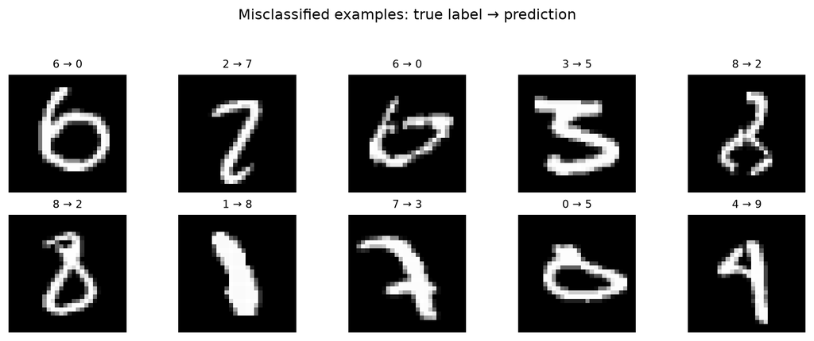

**Callout-answerAnswer**

```
train_cnn.py
```

```python
def train_cnn(model, train_loader, device, epochs=3, lr=1e-3):
    """
    Train a CNN and return its mean loss for every epoch.
    """
    loss_fn = nn.CrossEntropyLoss()
    optimizer = torch.optim.Adam(
        model.parameters(), lr=lr
    )
    history = []

    for epoch in range(epochs):
        model.train()
        running_loss = 0.0

        for batch_images, batch_labels in train_loader:
            batch_images, batch_labels = to_device(
                (batch_images, batch_labels), device
            )
            optimizer.zero_grad()
            logits = model(batch_images)
            loss = loss_fn(logits, batch_labels)
            loss.backward()
            optimizer.step()
            running_loss += (
                loss.item() * batch_images.size(0)
            )

        epoch_loss = (
            running_loss / len(train_loader.dataset)
        )
        history.append(epoch_loss)
        print(
            f"Epoch {epoch + 1}/{epochs} - "
            f"loss: {epoch_loss:.4f}"
        )

    return history


set_seed(42)
cnn = CNNClassifier().to(device)
cnn_history = train_cnn(
    cnn, train_loader, device, epochs=3
)
```

### Comparing the classifiers

print(

f"{'Model':<8}"

f"{'Parameters':>14}"

f"{'Test accuracy':>18}"

)

Model Parameters Test accuracy

print(

f"{'MLP':<8}"

f"{count_parameters(mlp):>14,}"

f"{100 * mlp_accuracy:>17.2f}%"

)

MLP 101,770 96.23%

print(

f"{'CNN':<8}"

f"{count_parameters(cnn):>14,}"

f"{100 * cnn_accuracy:>17.2f}%"

)

CNN 206,922 98.57%

The CNN usually performs better because local strokes and edges can be recognised wherever they occur in an image. However, one short training run does not establish that one architecture is universally superior. Performance also depends on parameter count, data, optimisation, and hyperparameters.

**TipQuestions for discussion**

1. Which model has more trainable parameters in this implementation?
2. Why can a convolution recognise the same type of edge in different image locations?
3. Compare the error plots. Do the models appear to fail on the same kinds of ambiguous digits?

**TipApplication to process data**

CNNs are useful when location and local neighbourhoods matter—for example, camera images, two-dimensional concentration fields, thermal images, spatial sensor arrays, and some time-frequency representations. A CNN is not automatically the best model for an ordinary table of unrelated process variables.

## Part C: Conditional variational autoencoder

The MLP and CNN learned to predict labels. An **autoencoder** has a different objective: it compresses an input into a **latent vector** and then reconstructs the original input.

```
image -> encoder -> latent vector -> decoder -> reconstruction
```

A standard autoencoder can learn useful compressed representations, but its latent vectors are not required to follow a known distribution. Empty regions or abrupt boundaries can therefore occur in its latent space. A vector sampled from a standard normal distribution may land in a region the decoder never encountered during training and produce a poor image.

A **variational autoencoder (VAE)** instead makes the encoder describe a probability distribution. For each image, the encoder predicts a mean $\boldsymbol{\mu}$ and log variance $\log\boldsymbol{\sigma}^2$. A latent vector is sampled with

$$\mathbf{z}
=
\boldsymbol{\mu}
+
\exp\left(
\frac{1}{2}\log\boldsymbol{\sigma}^2
\right)
\odot
\boldsymbol{\epsilon},
\qquad
\boldsymbol{\epsilon}
\sim
\mathcal{N}(\mathbf{0},\mathbf{I}).$$

This expression is called the **reparameterisation trick**. It writes the random sample as a differentiable transformation of $\boldsymbol{\mu}$ and $\log\boldsymbol{\sigma}^2$, allowing gradients to reach the encoder.

## Conditioning on a digit label

Our model is also **conditional**. The encoder receives an image and its digit label. The decoder receives a latent sample and the same label.

```
image + label -> encoder -> mu, logvar -> sample z
                                 z + label -> decoder -> image
```

At generation time, the label controls which digit is requested and $\mathbf{z}$ controls variation within that class, such as stroke width or slant. The label does not determine one unique latent vector: we independently sample $\mathbf{z} \sim \mathcal{N}(\mathbf{0},\mathbf{I})$ for each generated example.

The CVAE is fully connected so that the new ideas are the latent distribution, reparameterisation, and generative loss rather than additional convolutional shape calculations.

| Quantity | Shape | Meaning |
| --- | --- | --- |
| Flattened image | `[B, 784]` | Pixel values |
| One-hot label | `[B, 10]` | Requested digit class |
| Encoder input | `[B, 794]` | Image and label together |
| Hidden representation | `[B, 256]` | Shared encoder features |
| Mean and log variance | `[B, 2]` each | Parameters of the latent distribution |
| Decoder input | `[B, 12]` | Sampled latent vector and label |
| Reconstruction logits | `[B, 1, 28, 28]` | Unnormalised output pixels |

### Task 6 : Build the conditional VAE

Implement `ConditionalVAE`. Complete its layers and the `encode`, `reparameterize`, `decode`, and `forward` methods.

**TipImplementation guidance**

Use `F.one_hot(labels, num_classes=10).float()` to represent labels. In the encoder:

1. reshape each image to 784 values;
2. concatenate the image and one-hot label along `dim=1`;
3. map 794 inputs through a 256-neuron ReLU hidden layer; and
4. use separate linear layers to produce two latent means and two latent log variances.

In `reparameterize`, calculate the standard deviation with `torch.exp(0.5 * logvar)` and draw noise with `torch.randn_like`.

In the decoder, concatenate the two latent values and ten label values, then map 12 inputs through 256 hidden neurons to 784 reconstruction logits. Reshape the output to `[-1, 1, 28, 28]`.

```
conditional_vae.py
```

```python
class ConditionalVAE(nn.Module):
    """A fully connected class-conditional VAE for MNIST."""

    def __init__(self, latent_dim=2, num_classes=10):
        super().__init__()
        self.latent_dim = latent_dim
        self.num_classes = num_classes

        self.encoder = None
        self.mu_layer = None
        self.logvar_layer = None
        self.decoder = None

    def _one_hot(self, labels):
        """Convert integer labels to one-hot vectors."""

    def encode(self, images, labels):
        """Return latent means and log variances."""

    def reparameterize(self, mu, logvar):
        """Sample latent vectors with the reparameterisation trick."""

    def decode(self, z, labels):
        """Decode latent vectors conditioned on labels."""

    def forward(self, images, labels):
        """Encode, sample and decode a labelled image batch."""
```

cvae = ConditionalVAE().to(device)

sample_images, sample_labels = to_device(

(images[:4], labels[:4]), device

)

with torch.no_grad():

sample_reconstruction, sample_mu, sample_logvar = cvae(

sample_images, sample_labels

)

print(cvae)

ConditionalVAE(

(encoder): Sequential(

(0): Linear(in_features=794, out_features=256, bias=True)

(1): ReLU()

)

(mu_layer): Linear(in_features=256, out_features=2, bias=True)

(logvar_layer): Linear(in_features=256, out_features=2, bias=True)

(decoder): Sequential(

(0): Linear(in_features=12, out_features=256, bias=True)

(1): ReLU()

(2): Linear(in_features=256, out_features=784, bias=True)

)

)

print(

"\nReconstruction logits: "

f"{tuple(sample_reconstruction.shape)}"

)

Reconstruction logits: (4, 1, 28, 28)

print(f"Latent mean: {tuple(sample_mu.shape)}")

Latent mean: (4, 2)

print(

"Latent log variance: "

f"{tuple(sample_logvar.shape)}"

)

Latent log variance: (4, 2)

**Callout-answerAnswer**

```
conditional_vae.py
```

```python
class ConditionalVAE(nn.Module):
    """A fully connected class-conditional VAE for MNIST."""

    def __init__(self, latent_dim=2, num_classes=10):
        super().__init__()
        self.latent_dim = latent_dim
        self.num_classes = num_classes

        self.encoder = nn.Sequential(
            nn.Linear(
                28 * 28 + num_classes, 256
            ),
            nn.ReLU(),
        )
        self.mu_layer = nn.Linear(256, latent_dim)
        self.logvar_layer = nn.Linear(
            256, latent_dim
        )
        self.decoder = nn.Sequential(
            nn.Linear(
                latent_dim + num_classes, 256
            ),
            nn.ReLU(),
            nn.Linear(256, 28 * 28),
        )

    def _one_hot(self, labels):
        return F.one_hot(
            labels, num_classes=self.num_classes
        ).float()

    def encode(self, images, labels):
        flat_images = images.reshape(
            images.size(0), -1
        )
        encoder_input = torch.cat(
            (flat_images, self._one_hot(labels)),
            dim=1,
        )
        hidden = self.encoder(encoder_input)
        return (
            self.mu_layer(hidden),
            self.logvar_layer(hidden),
        )

    def reparameterize(self, mu, logvar):
        standard_deviation = torch.exp(
            0.5 * logvar
        )
        epsilon = torch.randn_like(
            standard_deviation
        )
        return mu + standard_deviation * epsilon

    def decode(self, z, labels):
        decoder_input = torch.cat(
            (z, self._one_hot(labels)), dim=1
        )
        logits = self.decoder(decoder_input)
        return logits.reshape(-1, 1, 28, 28)

    def forward(self, images, labels):
        mu, logvar = self.encode(images, labels)
        z = self.reparameterize(mu, logvar)
        reconstruction_logits = self.decode(
            z, labels
        )
        return reconstruction_logits, mu, logvar


cvae = ConditionalVAE().to(device)
print(cvae)
```

## The VAE loss

The CVAE balances two goals:

1. **Reconstruction:** reproduce the input image accurately.
2. **Regularisation:** keep the encoded distributions near a standard normal distribution so that $\mathbf{z} \sim \mathcal{N}(\mathbf{0},\mathbf{I})$ can be sampled during generation.

The reconstruction term is binary cross-entropy over all pixels,

$$\mathcal{L}_{\mathrm{reconstruction}}
=
-\sum_j
\left[
x_j\log \hat{x}_j
+
(1-x_j)\log(1-\hat{x}_j)
\right].$$

The Kullback–Leibler (KL) divergence for a diagonal Gaussian is

$$\mathcal{L}_{\mathrm{KL}}
=
-\frac{1}{2}
\sum_k
\left(
1+\log\sigma_k^2-\mu_k^2-\sigma_k^2
\right).$$

The total loss is

$$\mathcal{L}
=
\mathcal{L}_{\mathrm{reconstruction}}
+
\mathcal{L}_{\mathrm{KL}}.$$

We sum over pixels and latent dimensions, then divide by the batch size to report each component per image.

**ImportantLogits and sigmoid**

`F.binary_cross_entropy_with_logits` combines sigmoid and binary cross-entropy in one numerically stable calculation. Pass the raw decoder logits to the loss. Apply `torch.sigmoid` only when converting logits into pixel values for display.

### Task 7 : Calculate the CVAE loss

Implement `cvae_loss`. Return the total, reconstruction, and KL losses so that training can report each component.

**TipImplementation guidance**

Use `F.binary_cross_entropy_with_logits(..., reduction="sum")` and divide by `images.size(0)`.

Calculate KL divergence with

`-0.5 * torch.sum(1 + logvar - mu.pow(2) - logvar.exp())`

and divide it by the same batch size.

```
cvae_loss.py
```

```python
def cvae_loss(
    reconstruction_logits,
    images,
    mu,
    logvar,
):
    """
    Return total, reconstruction and KL loss per image.
    """
```

sample_total, sample_reconstruction_loss, sample_kl = (

cvae_loss(

sample_reconstruction,

sample_images,

sample_mu,

sample_logvar,

)

)

print(f"Initial total loss: {sample_total.item():.2f}")

Initial total loss: 546.06

print(

"Initial reconstruction loss: "

f"{sample_reconstruction_loss.item():.2f}"

)

Initial reconstruction loss: 546.06

print(f"Initial KL loss: {sample_kl.item():.2f}")

Initial KL loss: 0.01

**Callout-answerAnswer**

```
cvae_loss.py
```

```python
def cvae_loss(
    reconstruction_logits,
    images,
    mu,
    logvar,
):
    """
    Return total, reconstruction and KL loss per image.
    """
    batch_size = images.size(0)

    reconstruction = (
        F.binary_cross_entropy_with_logits(
            reconstruction_logits,
            images,
            reduction="sum",
        )
        / batch_size
    )
    kl_divergence = (
        -0.5
        * torch.sum(
            1
            + logvar
            - mu.pow(2)
            - logvar.exp()
        )
        / batch_size
    )
    total = reconstruction + kl_divergence
    return total, reconstruction, kl_divergence
```

### Task 8 : Train the conditional VAE

Implement `train_cvae`. Its optimisation sequence is familiar, but the forward pass now returns reconstruction logits, mean, and log variance. Accumulate all three loss values.

**TipImplementation guidance**

Inside each batch:

1. move the images and labels to `device`;
2. reset the gradients;
3. call `model(batch_images, batch_labels)`;
4. pass its three outputs and `batch_images` to `cvae_loss`;
5. check that `total` is finite;
6. run `total.backward()` and `optimizer.step()`; and
7. multiply each reported loss by `batch_size` before adding it to `sums`.

Use Adam with learning rate $10^{-3}$.

```
train_cvae.py
```

```python
def train_cvae(
    model,
    train_loader,
    device,
    epochs=8,
    lr=1e-3,
):
    """
    Train a conditional VAE and return component loss histories.
    """
    optimizer = torch.optim.Adam(
        model.parameters(), lr=lr
    )
    history = {
        "total": [],
        "reconstruction": [],
        "kl": [],
    }

    for epoch in range(epochs):
        model.train()
        sums = {
            "total": 0.0,
            "reconstruction": 0.0,
            "kl": 0.0,
        }

        for batch_images, batch_labels in train_loader:
            # Move the batch, reset gradients, run the model,
            # calculate and check losses, update parameters,
            # and add sample-weighted losses to sums.
            pass

        n_samples = len(train_loader.dataset)
        for name in history:
            history[name].append(
                sums[name] / n_samples
            )

        print(
            f"Epoch {epoch + 1}/{epochs} - "
            f"total: {history['total'][-1]:.2f}, "
            "reconstruction: "
            f"{history['reconstruction'][-1]:.2f}, "
            f"KL: {history['kl'][-1]:.2f}"
        )

    return history
```

set_seed(42)

cvae = ConditionalVAE(latent_dim=2).to(device)

cvae_history = train_cvae(

cvae, train_loader, device, epochs=8

)

Epoch 1/8 - total: 185.87, reconstruction: 179.00, KL: 6.87

Epoch 2/8 - total: 151.58, reconstruction: 147.43, KL: 4.15

Epoch 3/8 - total: 144.09, reconstruction: 139.89, KL: 4.21

Epoch 4/8 - total: 140.90, reconstruction: 136.67, KL: 4.23

Epoch 5/8 - total: 138.99, reconstruction: 134.75, KL: 4.24

Epoch 6/8 - total: 137.70, reconstruction: 133.43, KL: 4.27

Epoch 7/8 - total: 136.79, reconstruction: 132.48, KL: 4.31

Epoch 8/8 - total: 136.09, reconstruction: 131.74, KL: 4.35

The reconstruction loss should fall substantially. The KL term need not decrease monotonically: it penalises the encoder for moving away from the standard normal distribution while the reconstruction term encourages the latent variables to retain useful information.

```
plot_cvae_history.py
```

```python
def plot_cvae_history(history):
    """Plot total, reconstruction and KL loss per image."""
    epochs = np.arange(
        1, len(history["total"]) + 1
    )

    plt.figure(figsize=(9, 5))
    for name, values in history.items():
        plt.plot(
            epochs,
            values,
            marker="o",
            label=name.capitalize(),
        )
    plt.xlabel("Epoch")
    plt.ylabel("Loss per image")
    plt.title("Conditional VAE Training History")
    plt.xticks(epochs)
    plt.grid(True, alpha=0.3)
    plt.legend()
    plt.show()
```

plot_cvae_history(cvae_history)

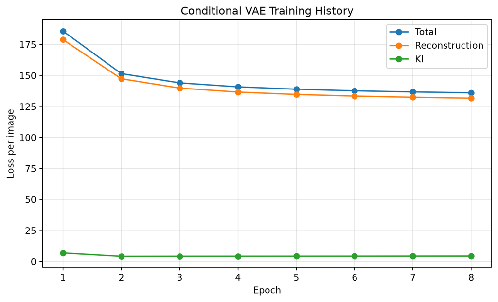

**Callout-answerAnswer**

```
train_cvae.py
```

```python
def train_cvae(
    model,
    train_loader,
    device,
    epochs=8,
    lr=1e-3,
):
    """
    Train a conditional VAE and return component loss histories.
    """
    optimizer = torch.optim.Adam(
        model.parameters(), lr=lr
    )
    history = {
        "total": [],
        "reconstruction": [],
        "kl": [],
    }

    for epoch in range(epochs):
        model.train()
        sums = {
            "total": 0.0,
            "reconstruction": 0.0,
            "kl": 0.0,
        }

        for batch_images, batch_labels in train_loader:
            batch_images, batch_labels = to_device(
                (batch_images, batch_labels),
                device,
            )
            optimizer.zero_grad()
            reconstruction_logits, mu, logvar = model(
                batch_images, batch_labels
            )
            (
                total,
                reconstruction,
                kl_divergence,
            ) = cvae_loss(
                reconstruction_logits,
                batch_images,
                mu,
                logvar,
            )

            if not torch.isfinite(total).item():
                raise FloatingPointError(
                    "CVAE loss became non-finite"
                )

            total.backward()
            optimizer.step()

            batch_size = batch_images.size(0)
            sums["total"] += (
                total.item() * batch_size
            )
            sums["reconstruction"] += (
                reconstruction.item() * batch_size
            )
            sums["kl"] += (
                kl_divergence.item() * batch_size
            )

        n_samples = len(train_loader.dataset)
        for name in history:
            history[name].append(
                sums[name] / n_samples
            )

        print(
            f"Epoch {epoch + 1}/{epochs} - "
            f"total: {history['total'][-1]:.2f}, "
            "reconstruction: "
            f"{history['reconstruction'][-1]:.2f}, "
            f"KL: {history['kl'][-1]:.2f}"
        )

    return history


set_seed(42)
cvae = ConditionalVAE(latent_dim=2).to(device)
cvae_history = train_cvae(
    cvae, train_loader, device, epochs=8
)
```

## Inspecting reconstructions

A generative model should be assessed visually as well as through its training loss. The first supplied helper places each original image directly above its reconstruction.

```
show_reconstructions.py
```

```python
@torch.no_grad()
def show_reconstructions(
    model,
    data_loader,
    device,
    n=10,
):
    """Display original images above CVAE reconstructions."""
    model.eval()
    images, labels = next(iter(data_loader))
    images, labels = to_device(
        (images[:n], labels[:n]), device
    )

    reconstruction_logits, _, _ = model(
        images, labels
    )
    reconstructions = torch.sigmoid(
        reconstruction_logits
    )

    images = to_cpu(images)
    labels = to_cpu(labels)
    reconstructions = to_cpu(reconstructions)

    fig, axes = plt.subplots(
        2, n, figsize=(1.5 * n, 3.5)
    )
    for column in range(n):
        axes[0, column].imshow(
            images[column].squeeze(0),
            cmap="gray",
            vmin=0,
            vmax=1,
        )
        axes[0, column].set_title(
            f"Digit {labels[column].item()}"
        )
        axes[0, column].axis("off")

        axes[1, column].imshow(
            reconstructions[column].squeeze(0),
            cmap="gray",
            vmin=0,
            vmax=1,
        )
        axes[1, column].axis("off")

    axes[0, 0].set_ylabel("Original")
    axes[1, 0].set_ylabel("Reconstructed")
    plt.tight_layout()
    plt.show()
```

show_reconstructions(

cvae, test_loader, device, n=10

)

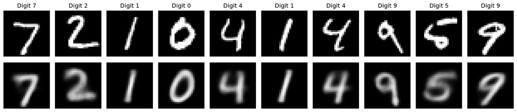

The reconstructions should resemble the input digits, but they will usually be smoother and less detailed. Compression, random sampling, and the KL regularisation all prevent the model from simply copying every pixel.

## Inspecting the two-dimensional latent space

Because the latent dimension is two, we can plot the mean produced by the encoder for each test image.

```
plot_latent_space.py
```

```python
@torch.no_grad()
def plot_latent_space(
    model,
    data_loader,
    device,
    max_points=5000,
):
    """Plot encoder means for labelled test images."""
    model.eval()
    means = []
    labels_seen = []
    n_collected = 0

    for images, labels in data_loader:
        images_device, labels_device = to_device(
            (images, labels), device
        )
        mu, _ = model.encode(
            images_device, labels_device
        )
        means.append(to_cpu(mu))
        labels_seen.append(labels)
        n_collected += len(images)

        if n_collected >= max_points:
            break

    means = torch.cat(means)[:max_points].numpy()
    labels_seen = (
        torch.cat(labels_seen)[:max_points].numpy()
    )
    assert means.shape[1] == 2

    plt.figure(figsize=(9, 7))
    scatter = plt.scatter(
        means[:, 0],
        means[:, 1],
        c=labels_seen,
        cmap="tab10",
        s=8,
        alpha=0.6,
    )
    plt.colorbar(
        scatter,
        ticks=range(10),
        label="Digit label",
    )
    plt.xlabel("Latent dimension 1")
    plt.ylabel("Latent dimension 2")
    plt.title("Conditional VAE Encoder Means")
    plt.grid(True, alpha=0.2)
    plt.show()
```

plot_latent_space(

cvae, test_loader, device, max_points=5000

)

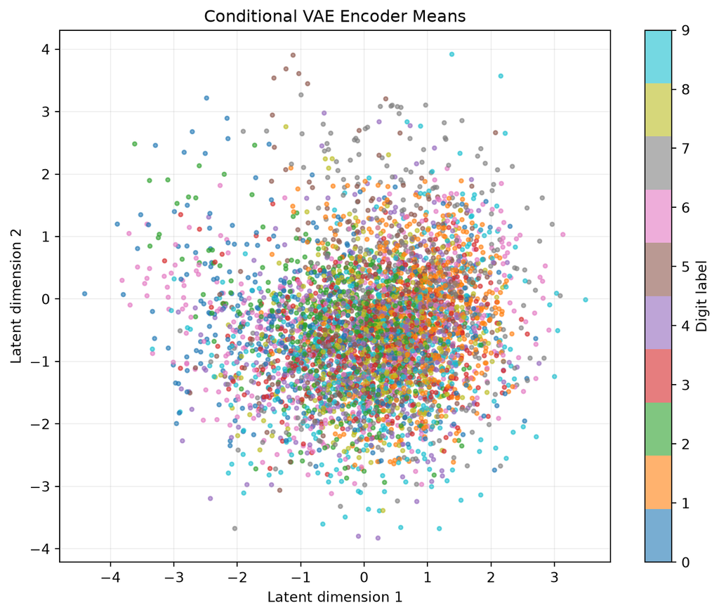

The colours may overlap substantially. This is not necessarily a failure: digit identity is provided separately to the decoder, so the latent vector does not have to form ten distinct label clusters. The latent variables can instead represent variation that is useful within each class.

## Sampling new digits

During generation there is no input image to encode. We sample

$$\mathbf{z}
\sim
\mathcal{N}(\mathbf{0},\mathbf{I})$$

and provide the requested digit label directly to the decoder.

The following plotting function accepts any tensor of single-channel images.

```
plot_image_grid.py
```

```python
def plot_image_grid(
    images,
    title,
    columns=8,
):
    """Display a tensor of single-channel images."""
    images = to_cpu(images)
    rows = int(
        np.ceil(len(images) / columns)
    )

    fig, axes = plt.subplots(
        rows,
        columns,
        figsize=(
            1.5 * columns,
            1.7 * rows,
        ),
        squeeze=False,
    )
    axes = axes.ravel()

    for ax, image in zip(axes, images):
        ax.imshow(
            image.squeeze(0),
            cmap="gray",
            vmin=0,
            vmax=1,
        )
        ax.axis("off")

    for ax in axes[len(images):]:
        ax.axis("off")

    fig.suptitle(title)
    plt.tight_layout()
    plt.show()
```

The generation harness is provided in full. Change `digit` to any integer from 0 to 9 and adjust `n_samples` to create more or fewer examples.

```
generate_digit.py
```

```python
@torch.no_grad()
def generate_digit(
    model,
    digit,
    n_samples,
    device,
):
    """Generate examples of one requested MNIST digit."""
    if (
        not isinstance(digit, (int, np.integer))
        or not 0 <= int(digit) <= 9
    ):
        raise ValueError(
            "digit must be an integer from 0 to 9"
        )
    if n_samples < 1:
        raise ValueError(
            "n_samples must be at least 1"
        )

    model.eval()
    labels = torch.full(
        (n_samples,),
        int(digit),
        dtype=torch.long,
        device=device,
    )
    z = torch.randn(
        n_samples,
        model.latent_dim,
        device=device,
    )
    generated = torch.sigmoid(
        model.decode(z, labels)
    )
    return to_cpu(generated)
```

set_seed(42)

generated_sevens = generate_digit(

cvae,

digit=7,

n_samples=16,

device=device,

)

plot_image_grid(

generated_sevens,

"Samples Requested as Digit 7",

columns=8,

)

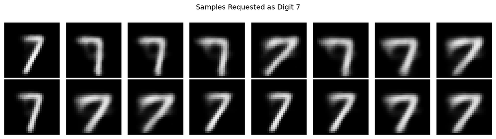

Each output uses label 7 but a different random latent vector. Consequently, the generated images should share their digit identity while differing in style.

## Holding latent style constant

To separate the two decoder inputs, we can hold one latent vector fixed while changing only the class label.

```
compare_conditions.py
```

```python
@torch.no_grad()
def compare_conditions(model, device):
    """Decode one latent vector under all ten labels."""
    model.eval()

    z = torch.randn(
        1,
        model.latent_dim,
        device=device,
    ).repeat(10, 1)
    labels = torch.arange(10, device=device)
    images = torch.sigmoid(
        model.decode(z, labels)
    )

    plot_image_grid(
        images,
        "One Latent Style Conditioned as Digits 0 to 9",
        columns=10,
    )
```

set_seed(7)

compare_conditions(cvae, device)

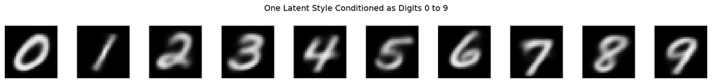

**TipQuestions for discussion**

1. Which visual properties persist when the class label changes?
2. Which properties appear to be controlled mainly by the label?
3. Why would a standard autoencoder be less suitable for sampling $\mathbf{z} \sim \mathcal{N}(\mathbf{0},\mathbf{I})$?
4. What trade-off does the KL term introduce?

**TipApplication to process data**

Autoencoders and VAEs can learn compact representations of high-dimensional process data. Possible applications include visualisation, monitoring, anomaly detection through reconstruction error, and synthetic-data exploration. A low reconstruction error alone does not prove that a sample is safe or physically valid; engineering constraints and independent validation remain essential.

## Conclusion

The three models used the same MNIST observations but learned for different purposes.

| Model | Purpose | Main advantage | Main limitation |
| --- | --- | --- | --- |
| MLP | Classification | Simple nonlinear baseline | Removes spatial layout immediately |
| CNN | Classification | Reuses local spatial filters | Adds architectural choices and computation |
| Conditional VAE | Reconstruction and generation | Regularised latent sampling with label control | Samples depend on training quality |

Despite their differences, all three models follow the same PyTorch pattern: move the model and batch to a device, calculate outputs and loss, backpropagate gradients, and update parameters. The architecture determines how information flows; the loss determines what the network is trained to achieve.

For chemical-engineering problems, an MLP is often a useful starting point for tabular process variables, a CNN is appropriate when local spatial structure matters, and an autoencoder or VAE can support representation learning and unsupervised monitoring. Model choice should follow the structure of the data and the intended engineering decision.

## Sources

- [Google Colab FAQ](https://research.google.com/colaboratory/faq.html)
- [PyTorch tensors and `Tensor.to`](https://docs.pytorch.org/docs/stable/generated/torch.Tensor.to.html)
- [PyTorch MPS backend](https://docs.pytorch.org/docs/stable/notes/mps.html)
- [PyTorch datasets and data loaders](https://docs.pytorch.org/tutorials/beginner/basics/data_tutorial.html)
- [Torchvision MNIST](https://docs.pytorch.org/vision/stable/generated/torchvision.datasets.MNIST.html)
- [PyTorch `CrossEntropyLoss`](https://docs.pytorch.org/docs/stable/generated/torch.nn.CrossEntropyLoss.html)
- [PyTorch binary cross-entropy with logits](https://docs.pytorch.org/docs/stable/generated/torch.nn.functional.binary_cross_entropy_with_logits.html)
- [Auto-Encoding Variational Bayes](https://arxiv.org/abs/1312.6114)
- [Learning Structured Output Representation using Deep Conditional Generative Models](https://proceedings.neurips.cc/paper/2015/hash/8d55a249e6baa5c06772297520da2051-Abstract.html)